# Restore Point-in-Time de Tabelas

## 6.2 Crie o arquivo de parâmetros da instância auxiliar e defina o ORACLE_SID

```bash
mkdir -p <CAMINHO AUXILIAR>/{adump,diag}

cat >> <CAMINHO AUXILIAR>/init<ORACLE_SID>.ora <<ENDEND
db_unique_name=caux001
db_name=cdb001
control_files=<CAMINHO AUXILIAR>/controlaux01.ora
diagnostic_dest=<CAMINHO AUXILIAR>/diag
audit_file_dest=<CAMINHO AUXILIAR>/adump
sga_target=2048M
sga_max_size=2048M
enable_pluggable_database=true
ENDEND

export ORACLE_SID=<ORACLE_SID>
```

Exemplo:

```bash
mkdir -p /u03/cdb001/restore/{adump,diag}

cat >> /u03/cdb001/restore/initcaux001.ora <<ENDEND
db_unique_name=caux001
db_name=cdb001
control_files=/u03/cdb001/restore/controlaux01.ora
diagnostic_dest=/u03/cdb001/restore/diag
audit_file_dest=/u03/cdb001/restore/adump
sga_target=2048M
sga_max_size=2048M
enable_pluggable_database=true
ENDEND

export ORACLE_SID=caux001
```

## 6.3 Inicie a instância em nomount

```sql
startup nomount pfile=<CAMINHO AUXILIAR>/init<ORACLE_SID>.ora
```

Exemplo:

```sql
startup nomount pfile=/u03/cdb001/restore/initcaux001.ora
```

## 6.4 Restaure o controlfile

É necessário restaurar um controlfile anterior ao Point-in-Time do recover.

```
run {
    restore controlfile from <backup piece>;
    sql "alter database mount";
}
```

Exemplo:

```
run {
    restore controlfile from '/u04/backup/cdb001/c-142496074-20221215-00';
    sql "alter database mount";
}
```

A partir deste ponto, DESCONECTE do catálogo.

## 6.5 Colocar em offline os datafiles

Como o `alter session set container` não funciona com `execute immediate`, é necessário executar o resultado do bloco abaixo:

```sql
set serveroutput on
begin
    for c_df in (select c.name, f.file#
                 from v$datafile f, v$containers c
                 where f.con_id = c.con_id
                 and f.file# NOT IN (<LISTA DE DATAFILES QUE SERAO RESTAURADOS>)
                 order by 1,2) loop
        dbms_output.put_line('alter session set container='||c_df.name||';');
        dbms_output.put_line('alter database datafile '||c_df.file#||' offline drop'||';');
    end loop;
end;
/
```

Exemplo:

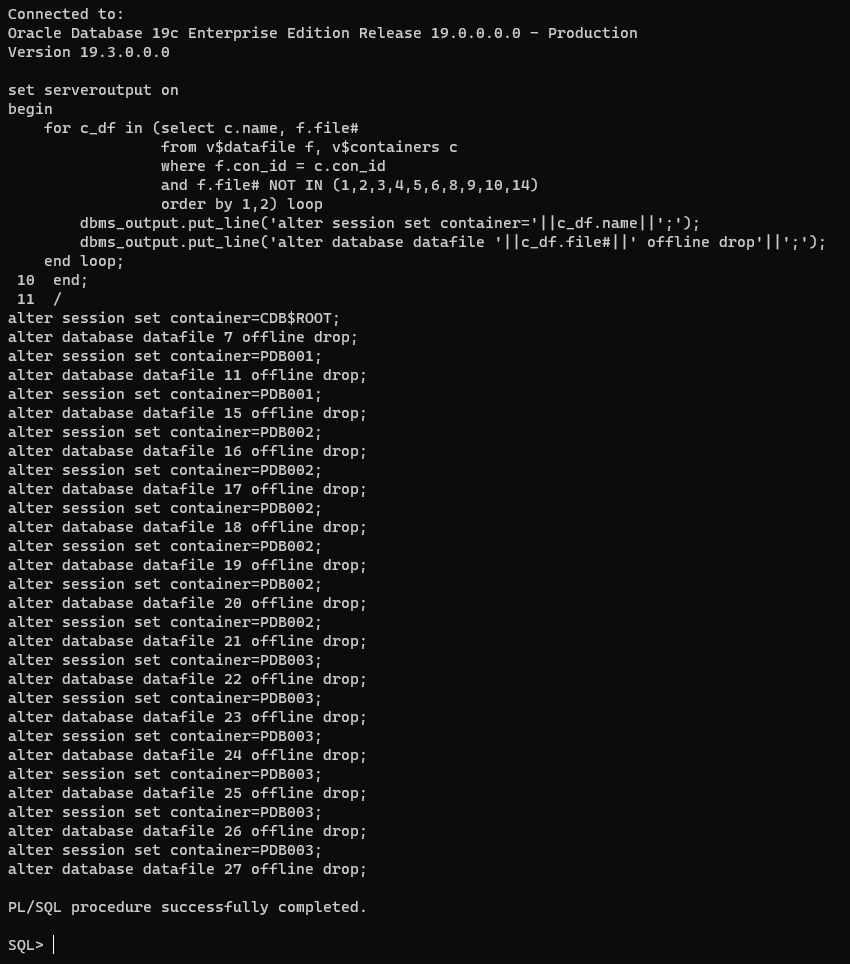

Colocando datafiles offline - Parte 1

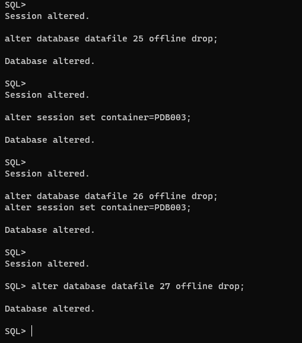

Colocando datafiles offline - Parte 2

```sql
set serveroutput on
begin
    for c_df in (select c.name, f.file#
                 from v$datafile f, v$containers c
                 where f.con_id = c.con_id
                 and f.file# NOT IN (1,2,3,4,5,6,8,9,10,14)
                 order by 1,2) loop
        dbms_output.put_line('alter session set container='||c_df.name||';');
        dbms_output.put_line('alter database datafile '||c_df.file#||' offline drop'||';');
    end loop;
end;
/
```

## 6.6 Catalogue os backup pieces necessários

Como o controlfile restaurado é anterior ao ponto de corte, será necessário catalogar os backup pieces gerados entre o backup do controlfile até o backup do último archivelog necessário.

### 6.6.1 Identificar os backup pieces - Executar no BANCO DE ORIGEM

```
list backup of archivelog from time "to_date('<DATA DO BACKUP DO CONTROLFILE>, 'dd/mm/yyyy hh24:mi')" until time "to_date('<DATA DE CORTE>', 'dd/mm/yyyy hh24:mi')";
```

Exemplo:

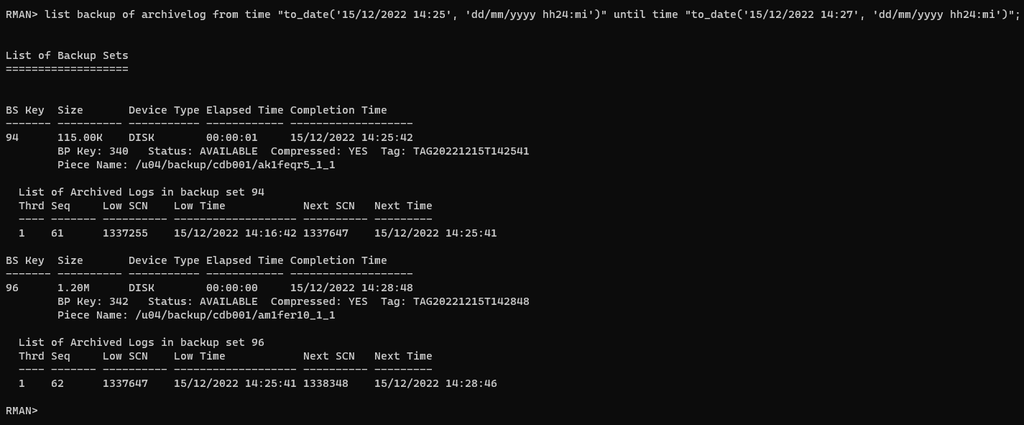

Identicando backup pieces

```
list backup of archivelog from time "to_date('15/12/2022 14:25', 'dd/mm/yyyy hh24:mi')" until time "to_date('15/12/2022 14:27', 'dd/mm/yyyy hh24:mi')";
```

### 6.6.2 Executar no banco AUXILIAR os comandos de catalog

```
catalog backuppiece <caminho 1>, <...>, <caminho n>;
```

Exemplo:

```
catalog backuppiece '/u04/backup/cdb001/ak1feqr5_1_1', '/u04/backup/cdb001/am1fer10_1_1';
```

## 6.7 Executar o preview do Restore

Executar o `restore database preview` com o mesmo `set until scn|time` usado no restore:

```
run {
    set until time "to_date('15/12/2022 14:27', 'DD/MM/YYYY HH24:MI')";

    set newname for database "CDB$ROOT" to '<CAMINHO AUXILIAR>/%f_%b';
    set newname for database "PDB$SEED" to '<CAMINHO AUXILIAR>/%f_%b';
    set newname for database "<PDB DA TABELA A SER RESTAURADA>" to '<CAMINHO AUXILIAR>/%f_%b';

    restore datafile 1, 2, <...>, <LISTA DE DATAFILES A SEREM RESTAURADOS>
        PREVIEW;
}
```

Exemplo:

```
run {
    set until time "to_date('15/12/2022 14:27', 'DD/MM/YYYY HH24:MI')";

    set newname for database "CDB$ROOT" to '/u03/cdb001/restore/%f_%b';
    set newname for database "PDB$SEED" to '/u03/cdb001/restore/%f_%b';
    set newname for database "PDB001" to '/u03/cdb001/restore/%f_%b';

    restore datafile 1,2,3,4,5,6,8,9,10,14
        PREVIEW;
}
```

No resultado do preview devemos tomar nota dos archives que serão usados:

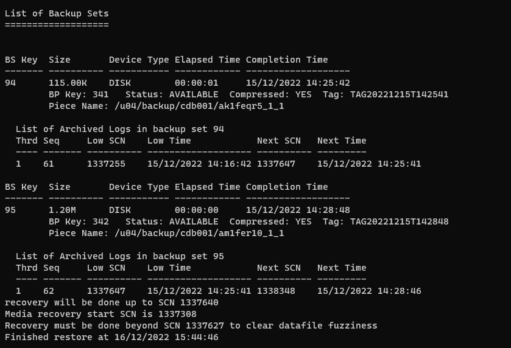

Archives que serão usados no recover

Esses archives deverão ser restaurados via `restore archivelog`.

## 6.8 Monte e execute o script de Restore

```
run {
    allocate channel <...>

    set until scn <SCN>;    # ou until time <DATA>

    set newname for database "CDB$ROOT" to '<CAMINHO AUXILIAR>/%f_%b';
    set newname for database "PDB$SEED" to '<CAMINHO AUXILIAR>/%f_%b';
    set newname for database "<PDB DA TABELA A SER RESTAURADA>" to '<CAMINHO AUXILIAR>/%f_%b';

    restore datafile 1, 2, <...>, <LISTA DE DATAFILES A SEREM RESTAURADOS>

    # UMA LINHA PARA CADA DATAFILE RESTAURADO
    # NAO USAR SWITCH DATAFILE ALL
    switch datafile 1;
    switch datafile 2;
    switch datafile 3;
    switch datafile 4;
    <...>
    switch datafile n;

    release channel <...>
}
```

Exemplo:

```
run {
    allocate channel ch1 device type disk;
    allocate channel ch2 device type disk;
    allocate channel ch3 device type disk;
    allocate channel ch4 device type disk;

    set until time "to_date('15/12/2022 14:27', 'DD/MM/YYYY HH24:MI')";

    set newname for database "CDB$ROOT" to '/u03/cdb001/restore/%f_%b';
    set newname for database "PDB$SEED" to '/u03/cdb001/restore/%f_%b';
    set newname for database "PDB001" to '/u03/cdb001/restore/%f_%b';

    restore datafile 1,2,3,4,5,6,8,9,10,14;

    switch datafile 1;
    switch datafile 2;
    switch datafile 3;
    switch datafile 4;
    switch datafile 5;
    switch datafile 6;
    switch datafile 8;
    switch datafile 9;
    switch datafile 10;
    switch datafile 14;

    release channel ch1;
    release channel ch2;
    release channel ch3;
    release channel ch4;
}
```

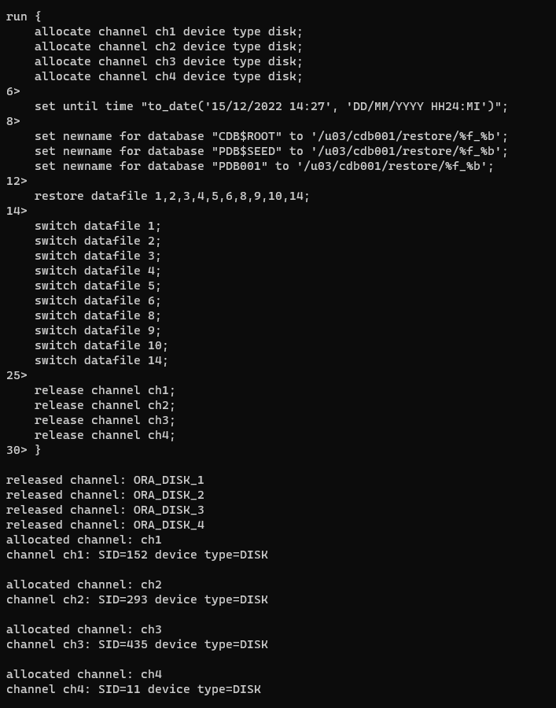

Executando Restore - Parte 1

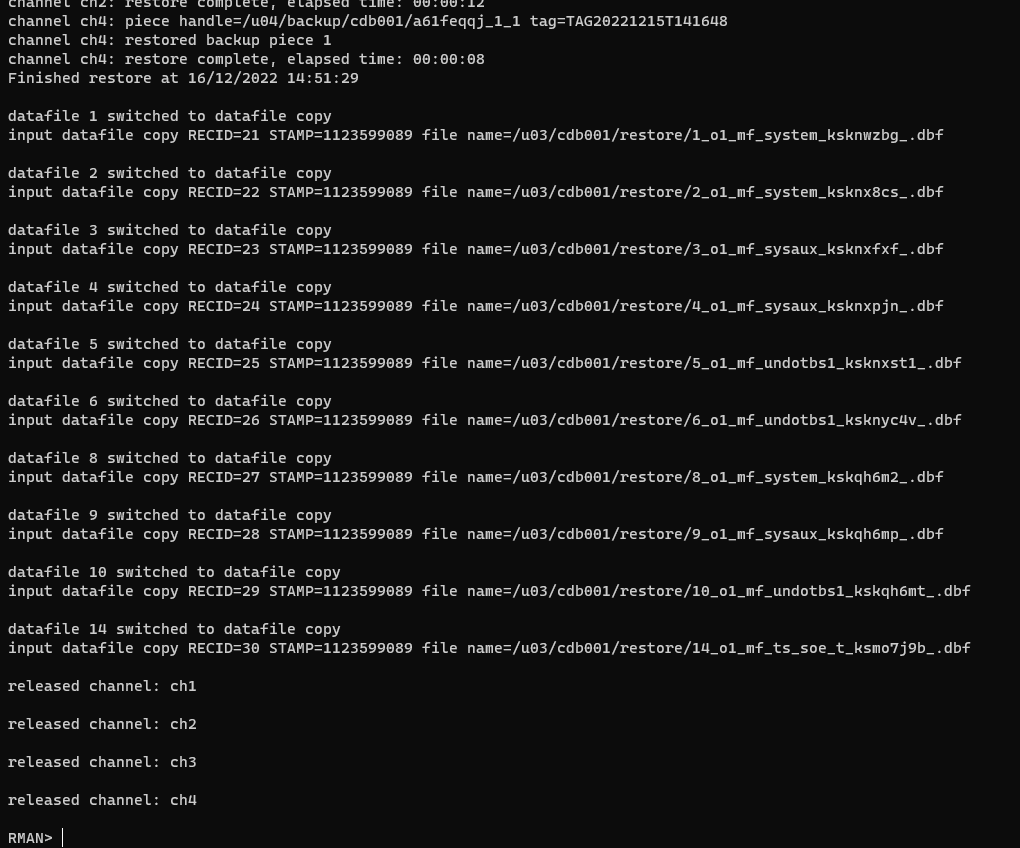

Executando Restore - Parte 2

## 6.9 Restaurar os archives necessários

Restaurar os archives identificados no *restore preview*:

```
run {
    set archivelog destination to '<CAMINHO AUXILIAR>/';
    restore archivelog from logseq <SEQ INICIAL> until logseq <SEQ FINAL>;
}
```

Exemplo:

```
run {
    set archivelog destination to '/u03/cdb001/restore';
    restore archivelog from logseq 61 until logseq 62;
}
```

## 6.10 Executar o Recover No SQL*PLUS

```sql
recover automatic database UNTIL TIME <DATA NO FORMATO YYYY/MM/DD:HH24:MI:SS> USING BACKUP CONTROLFILE;
```

Exemplo:

```sql
recover automatic database UNTIL TIME '2022/12/15:14:27:00' USING BACKUP CONTROLFILE;
```

## 6.11 Renomeie os redo logs no controlfile

Execute o script de `alter database rename file` gerado anteriormente. Exemplo:

```sql
alter database rename file '/u02/oradata/CDB001/onlinelog/o1_mf_1_ksknwbdr_.log' to '/u03/cdb001/restore/redo_1_1.log';
alter database rename file '/u03/fast_recovery_area/CDB001/onlinelog/o1_mf_1_ksknwd1m_.log' to '/u03/cdb001/restore/redo_1_2.log';
alter database rename file '/u02/oradata/CDB001/onlinelog/o1_mf_2_ksknwfrk_.log' to '/u03/cdb001/restore/redo_2_3.log';
alter database rename file '/u03/fast_recovery_area/CDB001/onlinelog/o1_mf_2_ksknwhjs_.log' to '/u03/cdb001/restore/redo_2_4.log';
alter database rename file '/u02/oradata/CDB001/onlinelog/o1_mf_3_ksknwk7k_.log' to '/u03/cdb001/restore/redo_3_5.log';
alter database rename file '/u03/fast_recovery_area/CDB001/onlinelog/o1_mf_3_ksknwlwv_.log' to '/u03/cdb001/restore/redo_3_6.log';
alter database rename file '/u02/oradata/CDB001/onlinelog/o1_mf_4_ksknwnkz_.log' to '/u03/cdb001/restore/redo_4_7.log';
alter database rename file '/u03/fast_recovery_area/CDB001/onlinelog/o1_mf_4_ksknwpds_.log' to '/u03/cdb001/restore/redo_4_8.log';
alter database rename file '/u02/oradata/CDB001/onlinelog/o1_mf_5_ksknwr1s_.log' to '/u03/cdb001/restore/redo_5_9.log';
alter database rename file '/u03/fast_recovery_area/CDB001/onlinelog/o1_mf_5_ksknwsq2_.log' to '/u03/cdb001/restore/redo_5_10.log';
alter database rename file '/u02/oradata/CDB001/onlinelog/o1_mf_6_ksknwvdr_.log' to '/u03/cdb001/restore/redo_6_11.log';
alter database rename file '/u03/fast_recovery_area/CDB001/onlinelog/o1_mf_6_ksknwx1x_.log' to '/u03/cdb001/restore/redo_6_12.log';
```

## 6.12 Abra o banco com resetlogs

Verifique que não há redo logs apontando para o caminho do banco original:

```sql
set lines 140
set numwidth 10
col member for a100
select group#, member
from v$logfile;
```

Para verificar que o banco pode ser aberto com `alter database open resetlogs`, execute a query abaixo:

```sql
set numwidth 30
set lines 900
set pagesize 50000;
col fuzzy for a5
alter session set nls_date_format = 'DD-MON-RRRR HH24:MI:SS';
select status,checkpoint_change#,checkpoint_time, resetlogs_change#, resetlogs_time, count(*), fuzzy
from v$datafile_header
where status <> 'OFFLINE'
group by status,checkpoint_change#,checkpoint_time, resetlogs_change#, resetlogs_time, fuzzy;
```

O resultado esperado é que todos os datafiles estejam com *FUZZY = NO*. Caso estejam proceda com o comando de resetlogs:

```sql
alter database open resetlogs;
alter session set container=<PDB DA TABELA DESAJADA>;
startup
```

Exemplo:

```sql
alter database open resetlogs;
alter session set container=PDB001;
startup
```

## 6.13 Crie o directory para o Data Pump e um tempfile

```sql
create directory DT_PUMP as '<CAMINHO AUXILIAR>';
alter session set container=<PDB RESTAURADO>;
alter tablespace temp add tempfile '<CAMINHO AUXILIAR>/temp01.dbf' size 100m autoextend on next 100m;
```

Exemplo:

```sql
create directory DT_PUMP as '/u03/cdb001/restore';
alter session set container=PDB001;
alter tablespace temp add tempfile '/u03/cdb001/restore/temp01.dbf' size 100m autoextend on next 100m;
```

## 6.14 Execute o export

```bash
expdp userid="<usuario>@'//<SERVIDOR>/<PDB>/<INSTANCIA>'" directory=DT_PUMP tables=<SCHEMA>.<TABLE> parallel=<DEGREE> dumpfile=<ARQUIVO DUMP> logfile=<ARQUIVO LOG> metrics=y
```

Exemplo:

```bash
expdp userid="system@'//linux01/pdb001/caux001'" directory=DT_PUMP tables=SOE.ORDER_ITEMS parallel=4 dumpfile=soe_order_items_%U.dmp logfile=soe_order_items.log metrics=y
```

# 7 Erros Comuns

## 7.1 *ORA-00376: file NNNN cannot be read at this time* em datafile de índices

Mesmo especificando o hint `FULL`, pode acontecer o erro *ORA-00376: file NNNN cannot be read at this time*. Exemplo:

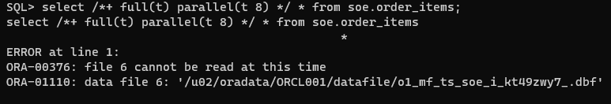

Erro ORA-00376 com hint FULL

Caso ocorra, siga as instruções abaixo:

- Identifique o tablespace ao qual o datafile pertence

  ```sql
  select tablespace_name
  from dba_data_files
  where file_id = <FILE ID reportado no erro>;
  ```

  Exemplo:

  ```sql
  select tablespace_name
  from dba_data_files
  where file_id = 6;
  ```

- Desabilite todas as constraints de PK e UK necessárias

  ```sql
  begin
      for c_cons in (select owner, constraint_name,table_name,index_owner,index_name
                    from dba_constraints
                    where (index_owner,index_name) in (select owner,index_name from dba_indexes
                                                        where tablespace_name=<TABLESPACE IDENTIFICADO NO PASSO ANTERIOR>)
                    ) loop
          execute immediate 'alter table "'||c_cons.owner||'"."'||c_cons.table_name||'" disable constraint "'||c_cons.constraint_name||'" cascade';
      end loop;
  end;
  /
  ```

  Exemplo:

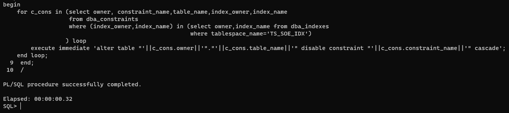

Desabilitando constraints

  ```sql
  begin
      for c_cons in (select owner, constraint_name,table_name,index_owner,index_name
                    from dba_constraints
                    where (index_owner,index_name) in (select owner,index_name from dba_indexes
                                                        where tablespace_name='TS_SOE_IDX')
                    ) loop
          execute immediate 'alter table "'||c_cons.owner||'"."'||c_cons.table_name||'" disable constraint "'||c_cons.constraint_name||'" cascade';
      end loop;
  end;
  /
  ```

- Drope o tablespace identificado - NÃO USE A OPÇÃO *INCLUDING CONTENTS AND DATAFILES*

  ```sql
  drop tablespace <TABLESPACE IDENTIFICADO NO PASSO ANTERIOR> including contents;
  ```

  Exemplo:

  ```sql
  drop tablespace TS_SOE_IDX including contents;
  ```

- Execute novamente a query

  Exemplo:

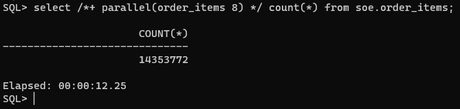

  Execução da query

## 7.2 *ORA-01152: file 1 was not restored from a sufficiently old backup* ao executar o *alter database open resetlogs*

Caso o comando de `alter database open resetlogs` falhe com o erro *ORA-01152: file 1 was not restored from a sufficiently old backup*, será necessário recriar o controlfile de acordo com as instruções abaixo:

- Gere um backup do controlfile para trace

  ```sql
  alter database backup controlfile to trace as <CAMINHO> resetlogs;
  ```

  Exemplo:

  ```sql
  alter database backup controlfile to trace as '/u03/orcl001/restore/controltrace.sql' resetlogs;
  ```

- Extraia do arquivo gerado o comando de create controlfile e edite para já renomear a base conter apenas os datafiles restaurados

  Exemplo:

  ```sql
  CREATE CONTROLFILE SET DATABASE "AUX001" RESETLOGS  NOARCHIVELOG
      MAXLOGFILES 16
      MAXLOGMEMBERS 3
      MAXDATAFILES 100
      MAXINSTANCES 8
      MAXLOGHISTORY 292
  LOGFILE
    GROUP 1 (
      '/u03/orcl001/restore/redo_1_1.log',
      '/u03/orcl001/restore/redo_1_2.log'
    ) SIZE 200M BLOCKSIZE 512,
    GROUP 2 (
      '/u03/orcl001/restore/redo_2_3.log',
      '/u03/orcl001/restore/redo_2_4.log'
    ) SIZE 200M BLOCKSIZE 512,
    GROUP 3 (
      '/u03/orcl001/restore/redo_3_5.log',
      '/u03/orcl001/restore/redo_3_6.log'
    ) SIZE 200M BLOCKSIZE 512,
    GROUP 4 (
      '/u03/orcl001/restore/redo_4_7.log',
      '/u03/orcl001/restore/redo_4_8.log'
    ) SIZE 200M BLOCKSIZE 512,
    GROUP 5 (
      '/u03/orcl001/restore/redo_5_9.log',
      '/u03/orcl001/restore/redo_5_10.log'
    ) SIZE 200M BLOCKSIZE 512,
    GROUP 6 (
      '/u03/orcl001/restore/redo_6_11.log',
      '/u03/orcl001/restore/redo_6_12.log'
    ) SIZE 200M BLOCKSIZE 512
  -- STANDBY LOGFILE
  DATAFILE
    '/u03/orcl001/restore/1_o1_mf_system_ksn5pyfk_.dbf',
    '/u03/orcl001/restore/2_o1_mf_sysaux_ksn5q8vj_.dbf',
    '/u03/orcl001/restore/3_o1_mf_undotbs1_ksn5k58k_.dbf',
    '/u03/orcl001/restore/5_o1_mf_ts_soe_t_ksn5k54c_.dbf'
  CHARACTER SET AL32UTF8
  ;

  ALTER DATABASE OPEN RESETLOGS;

  ALTER TABLESPACE TEMP ADD TEMPFILE '/u03/orcl001/restore/temp01.dbf' SIZE 1000m autoextend on next 100m;
  ```

- Renomeie o controlfile já existente

  Exemplo:

  ```bash
  mv /u03/orcl001/restore/controlaux01.ora /u03/orcl001/restore/controlaux01.ora.$(date '+%Y%m%d%H%M%S')
  ```

  Edite o parâmetro *db_name* no init para o mesmo usado no `create controlfile`, reinicie o banco em `nomount` e execute o script.

  Exemplo:

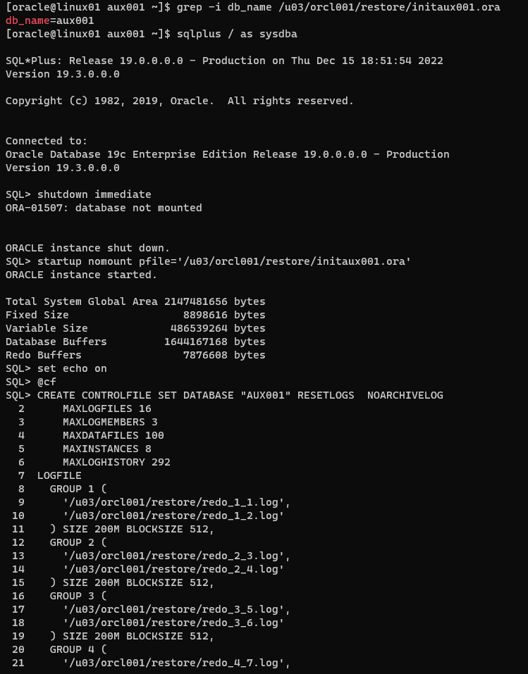

  Recriando o controlfile - Parte 1

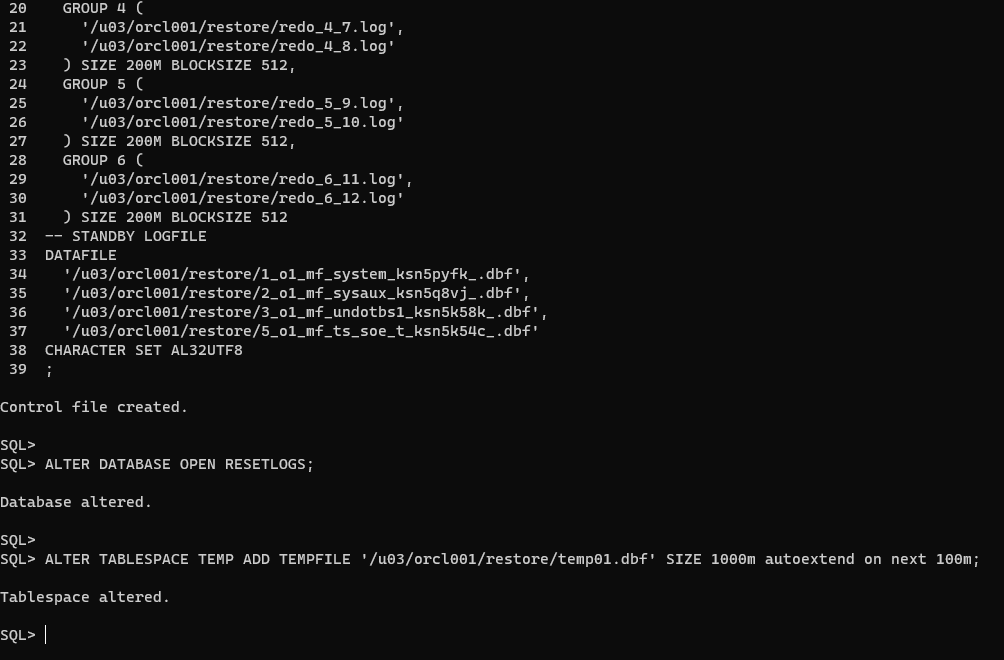

  Recriando o controlfile - Parte 2

# Referências

- [How To Locate SCN Time Of DROP TABLE Using LogMiner (Doc ID 93370.1)](https://support.oracle.com/epmos/faces/DocContentDisplay?id=93370.1)
- [How to Recover From a DROP / TRUNCATE / DELETE TABLE with RMAN (Doc ID 223543.1)](https://support.oracle.com/epmos/faces/DocContentDisplay?id=223543.1)
- [How to Recover From a DROP / TRUNCATE / DELETE TABLE with RMAN in 12c MT(Multitenant ) database (Doc ID 2214510.1)](https://support.oracle.com/epmos/faces/DocContentDisplay?id=2214510.1)
- [Recovering a Dropped Table from a User Managed (non-RMAN) Full Database Backup (Doc ID 96197.1)](https://support.oracle.com/epmos/faces/DocContentDisplay?id=96197.1)
- [Database Backup and Recovery Reference - 19c](https://docs.oracle.com/en/database/oracle/oracle-database/19/rcmrf/book-index.html)
- [Database Backup and Recovery User’s Guide - 19c](https://docs.oracle.com/en/database/oracle/oracle-database/19/bradv/index.html)
- [How to use pfile in recover table command (Doc ID 2430319.1)](https://support.oracle.com/epmos/faces/DocContentDisplay?id=2430319.1)
- [Recover Table Fails with RMAN-06034: at least 1 channel must be allocated to execute this command (Doc ID 2105325.1)](https://support.oracle.com/epmos/faces/DocContentDisplay?id=2105325.1)
- [After PITR to alternate server open resetlogs fails with ORA-01547 / ORA-01152: file 1 was not restored from a sufficiently old backup (Doc ID 2484229.1)](https://support.oracle.com/epmos/faces/DocContentDisplay?id=2484229.1)